# Introduction to linear modelling

## Learning objectives (linear modelling)

- Fit a linear model with multiple explanatory variables in `R`
- Interpret coefficients of a linear model with multiple explanatory variables
- Make a point prediction of the response for a new observation

## Introduction to linear modelling

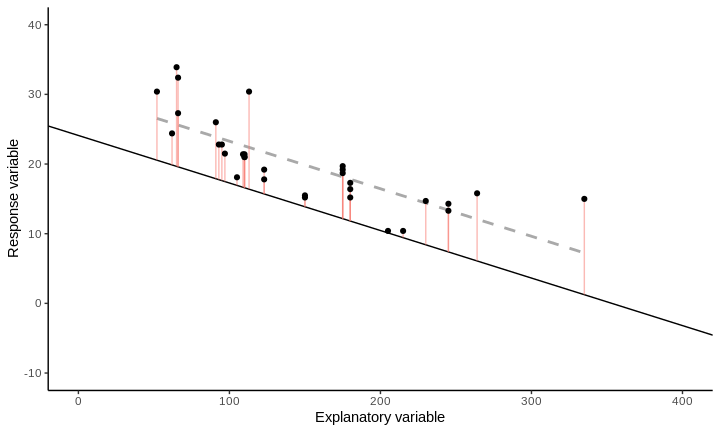

Gif inspired by https://crumplab.github.io/statistics/gifs.html

## The P\(\overline{\text{a}}\)ua dataset

The P\(\overline{\text{a}}\)ua dataset contains the following variables

- Age of P\(\overline{\text{a}}\)ua in years (calculated from counting rings in the cone)
- Length of P\(\overline{\text{a}}\)ua shell in centimeters
- Species of P\(\overline{\text{a}}\)ua: *Haliotis iris* (typically found in NZ) and *Haliotis australis* (less commonly found in NZ)

## How old am I?

[figure not shown]

*Haliotis australis*

[figure not shown]

*Haliotis iris*

## How old am I?

[figure not shown]

## How old am I?

```r
head(paua)
```

```
##              Species Length       Age
## 1      Haliotis iris   1.80  1.497884
## 2 Haliotis australis   5.40 11.877010
## 3 Haliotis australis   4.80  5.416991
## 4      Haliotis iris   5.75  4.497799
## 5      Haliotis iris   5.65  5.500789
## 6      Haliotis iris   2.80  2.500972
```

## Simple linear regression

\[Y_i = \beta_0 + \beta_1x_i + \epsilon_i\] \[\epsilon_i \sim \text{Normal}(0,\sigma^2)\] Here for observation \(i\)

- \(Y_i\) is the value of the response (in our case Age of P\(\overline{\text{a}}\)ua)
- \(x_i\) is the value of the explanatory variable (Length of P\(\overline{\text{a}}\)ua shell)
- \(\epsilon_i\) is the error term: the difference between \(Y_i\) and its expected value

## Simple linear regression

[figure not shown]

## Simple linear regression

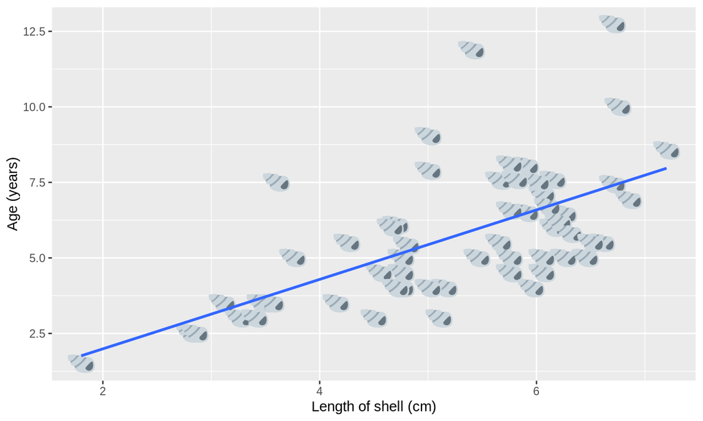

## But we have more information

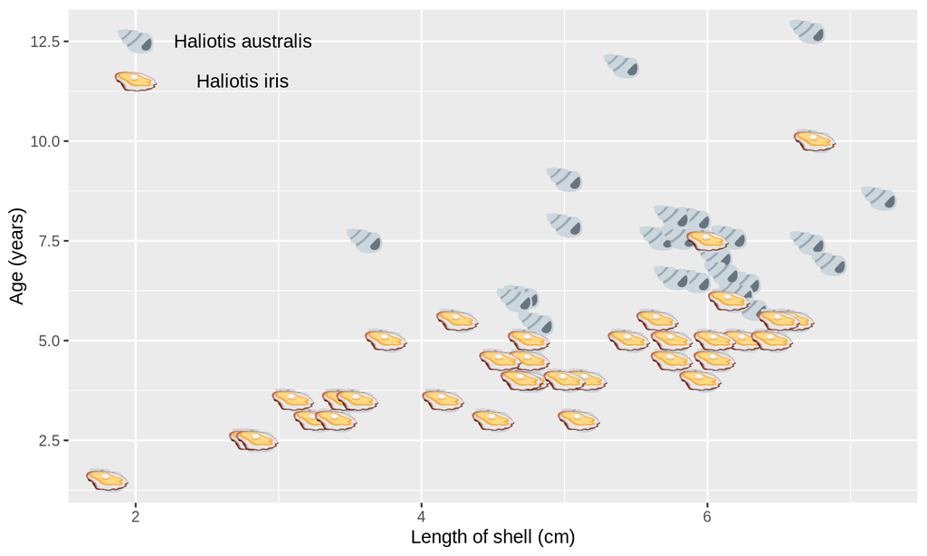

## Multiple linear regression

- To fit a simple linear model (one explanatory variable, Length)

```r
simple.mod <- lm(Age ~ Length, data = paua)
```

- To fit an ANOVA style model (Species as an explanatory variable)

```r
anova.mod <- lm(Age ~ Species, data = paua)
```

- Putting both variables in the model

```r
multiple.mod <- lm(Age ~ Length + Species, data = paua)
```

## Multiple linear regression

\[Y_i = \beta_0 + \beta_1x_i + \beta_2 z_i + \epsilon_i\] \[\epsilon_i \sim \text{Normal}(0,\sigma^2)\] Here for observation \(i\)

- \(Y_i\) is the value of the response (Age of P\(\overline{\text{a}}\)ua)
- \(x_i\) is the value of one explanatory variable (e.g., Length of P\(\overline{\text{a}}\)ua shell)
- \(z_i\) is the value of another explanatory variable (e.g., Species of P\(\overline{\text{a}}\)ua)
- \(\epsilon_i\) is the error term: the difference between \(Y_i\) and its expected value

## Multiple linear regression

For the \(i^{\text{th}}\) observation \[Y_i = \beta_0 + \beta_1x_i + \beta_2 z_i + \epsilon_i\] \[\downarrow\] \[\text{Age}_i = \beta_0 + \beta_1\text{Length}_i + \beta_2 \text{Species}_i + \epsilon_i\]

## Multiple linear regression

However, Species is not a numeric variable. So the equation becomes

\[\text{Age}_i = \beta_0 + \beta_1\text{Length}_i + \beta_2 \text{Haliotis iris?}_i + \epsilon_i\] Where

- Haliotis iris? is a dummy variable which \(=1\) if the \(i^{\text{th}}\) P\(\overline{\text{a}}\)ua is *Haliotis iris* and \(=0\) otherwise
- The baseline (intercept) \(\beta_0\) includes the reference factor variable. In this case *Haliotis australis*

## Multiple linear regression

- For *Haliotis australis* \[\text{Age}_i = \beta_0 + \beta_1\text{Length}_i + \epsilon_i\]
- For *Haliotis iris* \[\text{Age}_i = (\beta_0 + \beta_2)+ \beta_1\text{Length}_i + \epsilon_i\]

## Estimated coefficients

```r
summary(multiple.mod)
```

```
##
## Call:
## lm(formula = Age ~ Length + Species, data = paua)
##
## Residuals:
##     Min      1Q  Median      3Q     Max
## -2.1515 -0.6592 -0.2907  0.3190  4.6097
##
## Coefficients:
##                      Estimate Std. Error t value Pr(>|t|)
## (Intercept)            3.1640     0.9656   3.277  0.00179 **
## Length                 0.7599     0.1603   4.739 1.47e-05 ***
## SpeciesHaliotis iris  -2.4159     0.3906  -6.186 7.13e-08 ***
## ---
## Signif. codes:  0 '***' 0.001 '**' 0.01 '*' 0.05 '.' 0.1 ' ' 1
##
## Residual standard error: 1.363 on 57 degrees of freedom
## Multiple R-squared:  0.6347, Adjusted R-squared:  0.6219
## F-statistic: 49.52 on 2 and 57 DF,  p-value: 3.428e-13
```

## Interpreting the coefficients

- For every 1cm increase in Length we estimate the expected Age increases by 0.8 years
- We estimate that the expected age of a *Haliotis iris* is 2.4 years younger than that of a *Haliotis australis* of the same length

## Confidence intervals

```r
confint(multiple.mod)
```

```
##                           2.5 %    97.5 %
## (Intercept)           1.2304392  5.097599
## Length                0.4387857  1.080955
## SpeciesHaliotis iris -3.1980049 -1.633834
```

## Interpreting confidence intervals

- For every 1cm increase in Length we estimate the expected Age increases between 0.4 and 1.1 years
- We estimate that the expected age of a *Haliotis iris* is between 1.6 and 3.2 years younger than that of a *Haliotis australis* of the same length

## Estimated Age

- For a *Haliotis iris* of length 5cm

\[\hat{\text{Age}} = \hat{\beta_0} + \hat{\beta_1}5 + \hat{\beta_2}1\] \[\downarrow\]

\[\hat{\text{Age}} = 3.16 + 0.76 \times 5 - 2.42 \times 1\]

\[\downarrow\]

\[4.54\]

## Estimated Age in `R`

```r
## create new data frame with data we want to predict to
newdata <- data.frame(Length = 5, Species = "Haliotis iris")
## use predict() function
predict(multiple.mod, newdata = newdata)
```

```
##        1
## 4.547453
```

## Fitted model

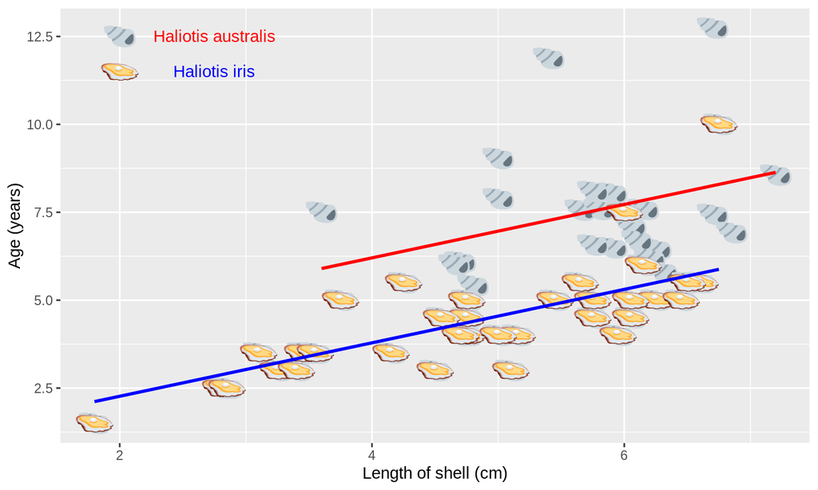

## Fitted model

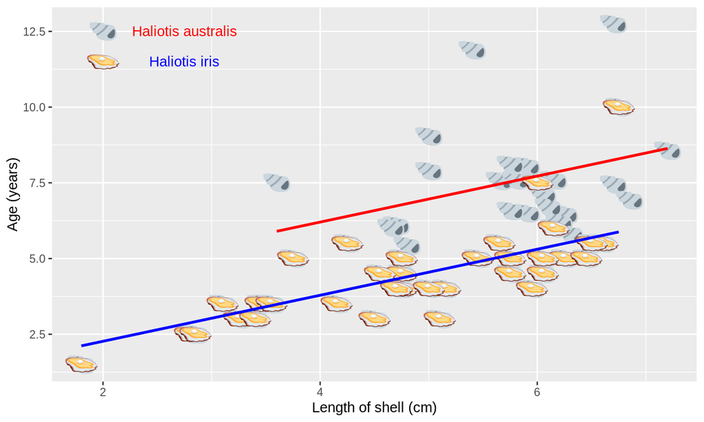

But, what if the lines aren't parallel?

## Next Time INTERACTIONS

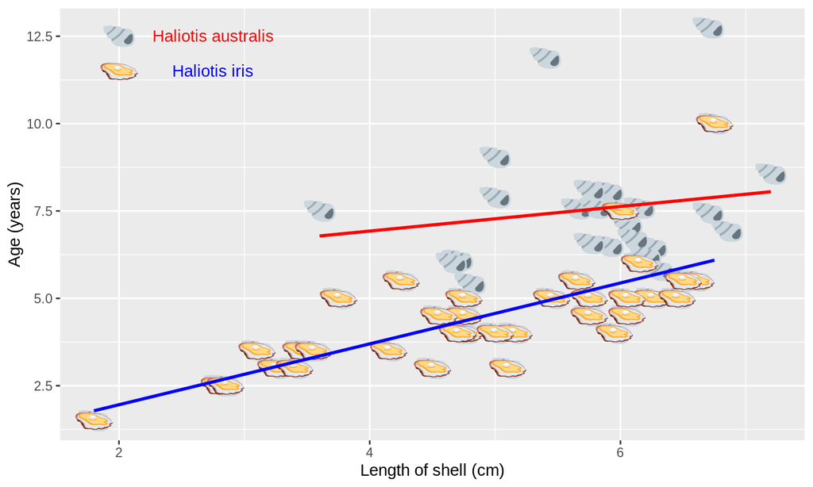

https://b.socrative.com/login/student/ Room Name: BIOSCI220